# G1401211012_Syifa Khairunnisa_Pertemuan 6 dan 7

Syifa Khairunnisa

2023-10-15

# Packages

```r
library(ggplot2)
library(tsibble)
library(tseries)
library(MASS)
library(forecast)
library(TSA)
library(TTR)
library(aTSA)
library(graphics)
```

# Data

```r
library(rio)
data <- import("https://raw.githubusercontent.com/syifaskn/MPDWPraktikum/main/Pertemuan%206%20dan%207/DataTempSulsel.csv")
data
```

```
##       Time MaxTemp
## 1   Mar-10   30.19
## 2   Apr-10   30.30
## 3   May-10   30.35
## 4   Jun-10   30.28
## 5   Jul-10   30.05
## 6   Aug-10   30.49
## 7   Sep-10   30.88
## 8   Oct-10   31.42
## 9   Nov-10   31.36
## 10  Dec-10   30.48
## 11  Jan-11   29.71
## 12  Feb-11   29.86
## 13  Mar-11   30.32
## 14  Apr-11   30.26
```

[output cut: 116 more lines]

```r
dim(data)
```

```
## [1] 130   2
```

# Mengubah data menjadi time series ‘ts’

```r
data.ts <- ts(data$MaxTemp)
```

# Membagi data (80:20)

Pembagian data ini dilakukan dengan proporsi / perbandingan, yaitu 80:20. 80% untuk data latih, dan 20% untuk data uji.

```r
data.train <- data[1:104,]
data.test <- data[105:130,]
train.ts <- ts(data.train$MaxTemp)
test.ts <- ts(data.test$MaxTemp)
```

# Eksplorasi Data

Sebelum masuk dalam tahap pemodelan, dilakukan eksplorasi data dengan plot deret waktu untuk melihat pola data.

## Plot Data Penuh

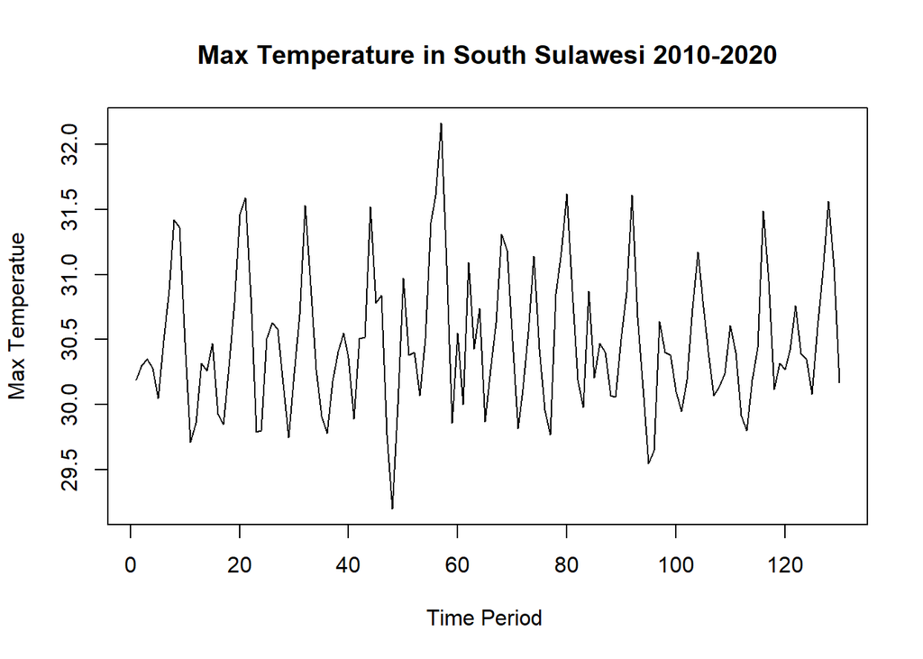

```r
ts.plot(data.ts, xlab="Time Period ", ylab="Max Temperatue",
        main = "Max Temperature in South Sulawesi 2010-2020")
```

Terlihat pada plot yang ditampilan bahwa data suhu maksimum yang digunakan berpola data musiman.

## Plot Data Latih

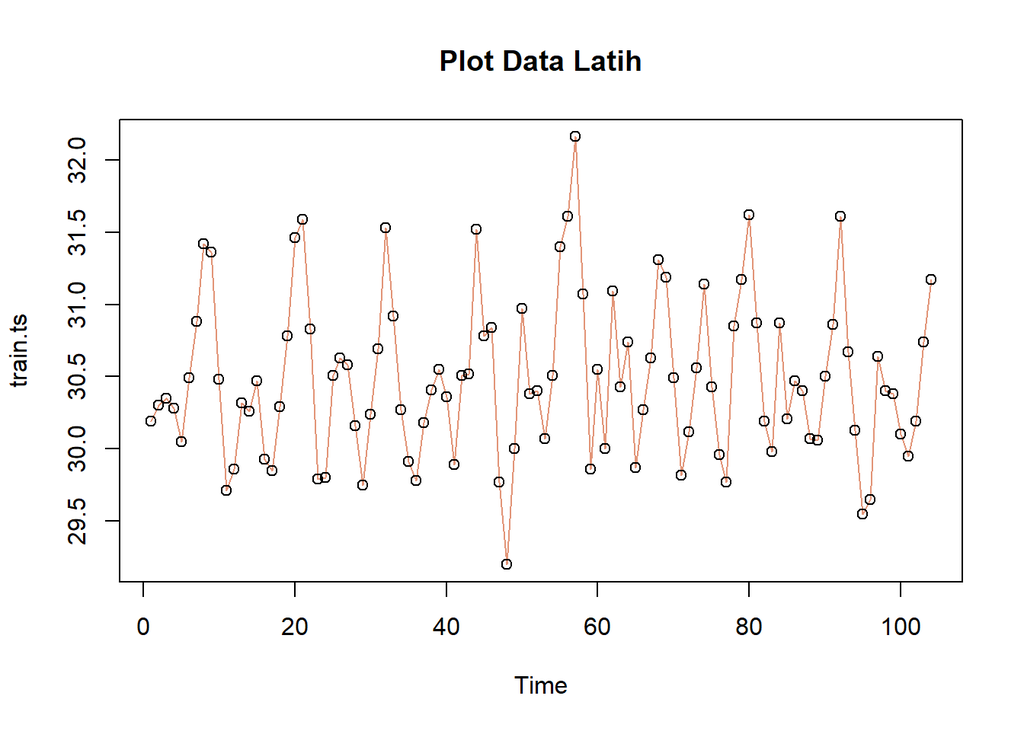

```r
plot(train.ts, col="#e29578",main="Plot Data Latih")
points(train.ts)
```

Berdasarkan plot data deret waktu pada data latih, terlihat bahwa data cenderung memiliki pola musiman sehingga mengindikasikan bahwa data stasioner dalam rataan maupun ragam. Namun, untuk memastikan hal tersebut, akan dilakukan uji lanjut ke depannya.

## Plot Data Uji

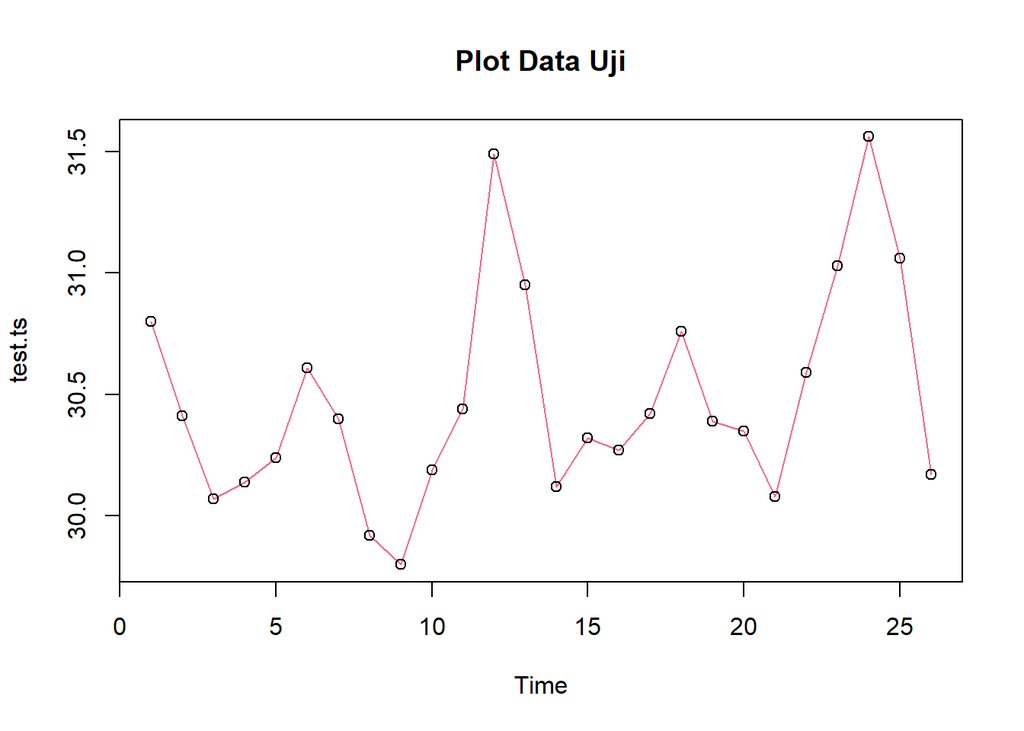

```r
plot(test.ts, col="#f26a8d",main="Plot Data Uji")
points(test.ts)
```

# Cek KEstasioneran Data

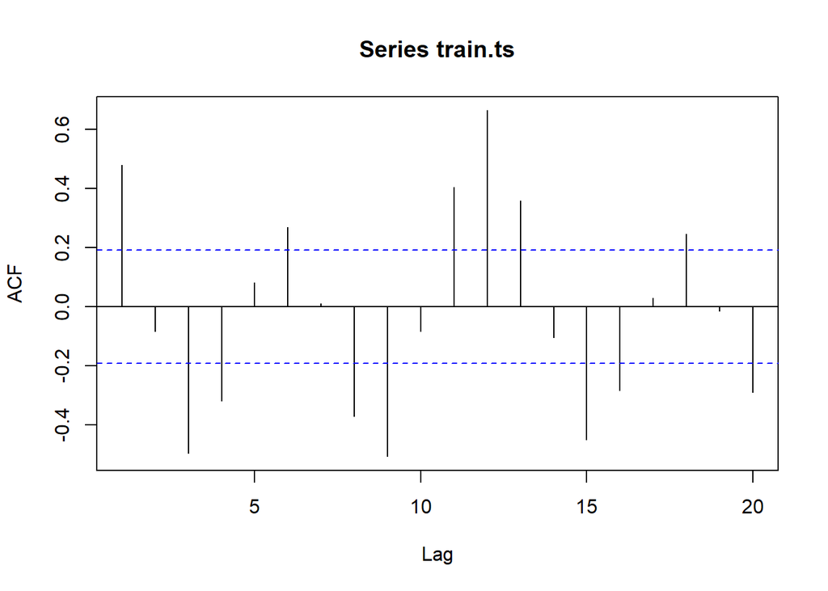

```r
# plot ACF
acf(train.ts)
```

Berdasarkan plot ACF, terlihat bahwa plot ACF pada data tersebut cenderung *tails off* dan membentuk gelombang sinus. Hal ini mengindikasi bahwa data stasioner dalam rataan.

```r
# uji ADF
tseries::adf.test(train.ts)
```

```
##
##  Augmented Dickey-Fuller Test
##
## data:  train.ts
## Dickey-Fuller = -4.0849, Lag order = 4, p-value = 0.01
## alternative hypothesis: stationary
```

$H_0$ : Data tidak stasioner dalam rataan

$H_1$ : Data stasioner dalam rataan

Berdasarkan uji ADF tersebut, didapat *p-value* sebesar 0.01 yang lebih kecil dari taraf nyata 5% sehingga tolak $H_0$ dan menandakan bahwa data stasioner dalam rataan. Hal ini sesuai dengan hasil eksplorasi menggunakan plot time series dan plot ACF.

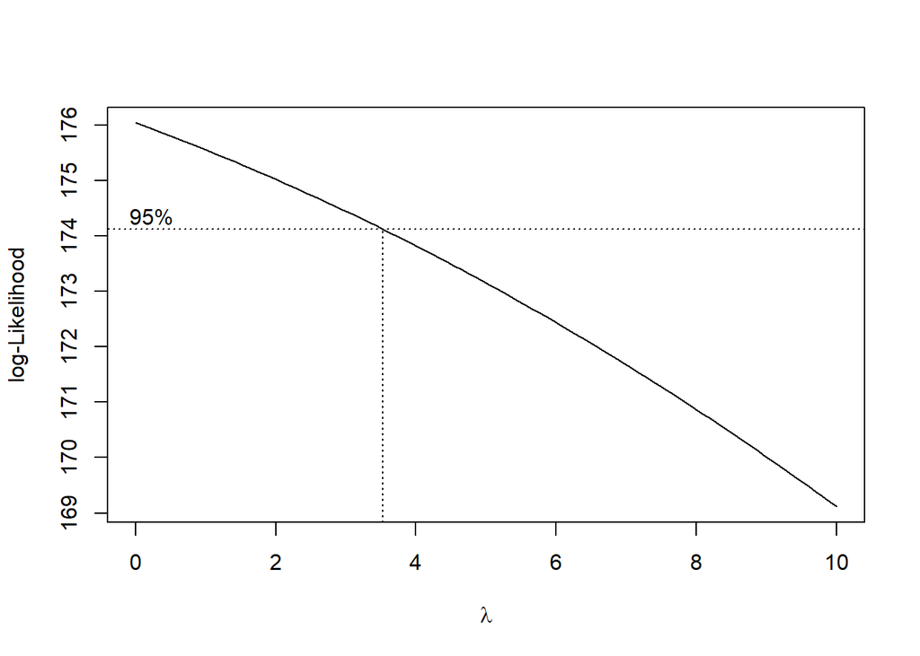

```r
# plot Box-Cox
index <- seq(1:104)
bc = boxcox(train.ts~index, lambda = seq(0,10,by=1))
```

```r
#Nilai Rounded Lambda
lambda <- bc$x[which.max(bc$y)]
lambda
```

```
## [1] 0
```

```r
#SK
bc$x[bc$y > max(bc$y) - 1/2 * qchisq(.95,1)]
```

```
##  [1] 0.0000000 0.1010101 0.2020202 0.3030303 0.4040404 0.5050505 0.6060606
##  [8] 0.7070707 0.8080808 0.9090909 1.0101010 1.1111111 1.2121212 1.3131313
## [15] 1.4141414 1.5151515 1.6161616 1.7171717 1.8181818 1.9191919 2.0202020
## [22] 2.1212121 2.2222222 2.3232323 2.4242424 2.5252525 2.6262626 2.7272727
## [29] 2.8282828 2.9292929 3.0303030 3.1313131 3.2323232 3.3333333 3.4343434
```

Plot Boxcox menunjukkan nilai *rounded value* ($\lambda$) optimum sebesar **0** dan pada selang kepercayaan 95% nilai memiliki batas bawah **0** dan batas atas **3.4343434**. Selang tersebut memuat nilai satu sehingga dapat dikatakan bahwa data stasioner dalam ragam.

# Identifikasi Model

## Plot ACF

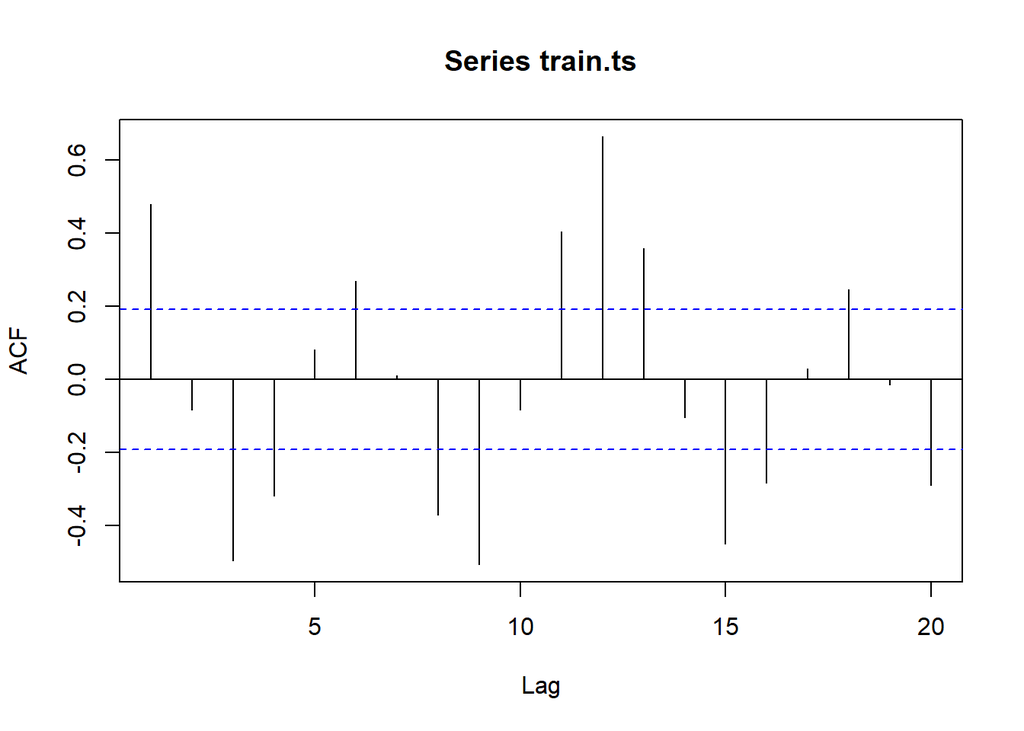

```r
acf(train.ts)
```

## Plot PACF

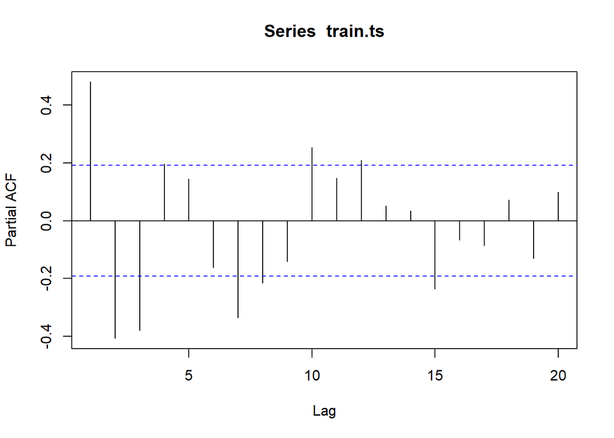

```r
pacf(train.ts)
```

## Plot EACF

Selain dengan plot ACF dan PACF, penentuan spesifikasi model dilakukan dengan *extended ACF* (EACF) berikut ini.

```r
eacf(train.ts)
```

```
## AR/MA
##   0 1 2 3 4 5 6 7 8 9 10 11 12 13
## 0 x o x x o x o x x o x  x  x  o
## 1 x o x x o x o x x o x  x  x  o
## 2 x x o o o o o o x x o  x  o  x
## 3 x x o o o o o o o o o  x  o  o
## 4 x x o x o o o o o o o  o  o  o
## 5 x x o x o o o o o o o  o  o  o
## 6 x x o o o o o o o o o  o  o  o
## 7 x o x x o o x o o o o  o  o  o
```

Menggunakan plot EACF, dapat diambil beberapa model dengan melihat ujung segitiga yang terbentuk, antara lain ARIMA(2,0,2), ARIMA(2,0,3), ARIMA(3,0,2), dan ARIMA(3,0,3).

# Pendugaan Parameter Model Tentatif

## ARIMA(0,0,1)

```r
model1 = Arima(train.ts, order=c(0,0,1),method="ML")
summary(model1) #AIC = 147.85
```

```
## Series: train.ts
## ARIMA(0,0,1) with non-zero mean
##
## Coefficients:
##          ma1     mean
##       0.4706  30.4854
## s.e.  0.0662   0.0687
##
## sigma^2 = 0.233:  log likelihood = -70.92
## AIC=147.85   AICc=148.09   BIC=155.78
##
## Training set error measures:
##                        ME      RMSE       MAE         MPE     MAPE      MASE
## Training set 0.0008426583 0.4779861 0.3849842 -0.02303913 1.258935 0.8169216
##                   ACF1
## Training set 0.1252057
```

```r
lmtest::coeftest(model1) #seluruh parameter signifikan
```

```
##
## z test of coefficients:
##
##            Estimate Std. Error  z value  Pr(>|z|)
## ma1        0.470590   0.066204   7.1082 1.176e-12 ***
## intercept 30.485390   0.068716 443.6423 < 2.2e-16 ***
## ---
## Signif. codes:  0 '***' 0.001 '**' 0.01 '*' 0.05 '.' 0.1 ' ' 1
```

## ARIMA(1,0,0)

```r
model2 = Arima(train.ts, order=c(1,0,0),method="ML")
summary(model2) #AIC = 150.29
```

```
## Series: train.ts
## ARIMA(1,0,0) with non-zero mean
##
## Coefficients:
##          ar1     mean
##       0.4838  30.4875
## s.e.  0.0858   0.0911
##
## sigma^2 = 0.2385:  log likelihood = -72.15
## AIC=150.29   AICc=150.53   BIC=158.23
##
## Training set error measures:
##                       ME     RMSE       MAE         MPE     MAPE      MASE
## Training set 0.001756445 0.483597 0.4011307 -0.01927028 1.312481 0.8511838
##                   ACF1
## Training set 0.2014914
```

```r
lmtest::coeftest(model2) #seluruh parameter signifikan
```

```
##
## z test of coefficients:
##
##            Estimate Std. Error  z value  Pr(>|z|)
## ar1        0.483786   0.085846   5.6355 1.746e-08 ***
## intercept 30.487478   0.091053 334.8321 < 2.2e-16 ***
## ---
## Signif. codes:  0 '***' 0.001 '**' 0.01 '*' 0.05 '.' 0.1 ' ' 1
```

## ARIMA(2,0,2)

```r
model3 = Arima(train.ts, order=c(2,0,2),method="ML")
summary(model3) #AIC = 107.85
```

```
## Series: train.ts
## ARIMA(2,0,2) with non-zero mean
##
## Coefficients:
##          ar1      ar2      ma1     ma2     mean
##       0.8927  -0.8462  -0.3516  0.6405  30.4824
## s.e.  0.0820   0.0730   0.1417  0.0768   0.0505
##
## sigma^2 = 0.152:  log likelihood = -47.93
## AIC=107.85   AICc=108.72   BIC=123.72
##
## Training set error measures:
##                       ME      RMSE       MAE        MPE      MAPE      MASE
## Training set 0.001084313 0.3804349 0.3028133 -0.0120535 0.9895729 0.6425581
##                     ACF1
## Training set 0.008550213
```

```r
lmtest::coeftest(model3) #seluruh parameter signifikan
```

```
##
## z test of coefficients:
##
##            Estimate Std. Error  z value Pr(>|z|)
## ar1        0.892720   0.082007  10.8859  < 2e-16 ***
## ar2       -0.846209   0.072971 -11.5965  < 2e-16 ***
## ma1       -0.351616   0.141735  -2.4808  0.01311 *
## ma2        0.640479   0.076785   8.3412  < 2e-16 ***
## intercept 30.482386   0.050508 603.5218  < 2e-16 ***
## ---
## Signif. codes:  0 '***' 0.001 '**' 0.01 '*' 0.05 '.' 0.1 ' ' 1
```

## ARIMA(2,0,3)

```r
model4 = Arima(train.ts, order=c(2,0,3),method="ML")
summary(model4) #AIC = 106.54
```

```
## Series: train.ts
## ARIMA(2,0,3) with non-zero mean
##
## Coefficients:
##          ar1      ar2      ma1     ma2     ma3     mean
##       0.9820  -0.9981  -0.6352  0.7176  0.3015  30.4776
## s.e.  0.0099   0.0034   0.0838  0.0928  0.0764   0.0486
##
## sigma^2 = 0.1408:  log likelihood = -46.27
## AIC=106.54   AICc=107.7   BIC=125.05
##
## Training set error measures:
##                       ME      RMSE       MAE          MPE      MAPE     MASE
## Training set 0.002738112 0.3642336 0.2903531 -0.007005955 0.9483917 0.616118
##                    ACF1
## Training set 0.09545984
```

```r
lmtest::coeftest(model4) #seluruh parameter signifikan
```

```
##
## z test of coefficients:
##
##             Estimate Std. Error   z value  Pr(>|z|)
## ar1        0.9819717  0.0098875   99.3144 < 2.2e-16 ***
## ar2       -0.9981238  0.0033705 -296.1352 < 2.2e-16 ***
## ma1       -0.6351903  0.0838134   -7.5786 3.492e-14 ***
## ma2        0.7175714  0.0928034    7.7322 1.057e-14 ***
## ma3        0.3015101  0.0763527    3.9489 7.851e-05 ***
## intercept 30.4776184  0.0485544  627.6998 < 2.2e-16 ***
## ---
## Signif. codes:  0 '***' 0.001 '**' 0.01 '*' 0.05 '.' 0.1 ' ' 1
```

## ARIMA(3,0,2)

```r
model5 = Arima(train.ts, order=c(3,0,2),method="ML")
summary(model5) #AIC = 98.49
```

```
## Series: train.ts
## ARIMA(3,0,2) with non-zero mean
##
## Coefficients:
##          ar1      ar2     ar3      ma1     ma2     mean
##       1.4505  -1.4571  0.4631  -0.9702  0.9963  30.4759
## s.e.  0.0937   0.0916  0.0919   0.0360  0.0632   0.0643
##
## sigma^2 = 0.1302:  log likelihood = -42.25
## AIC=98.49   AICc=99.66   BIC=117.01
##
## Training set error measures:
##                       ME      RMSE       MAE          MPE      MAPE      MASE
## Training set 0.003474481 0.3503061 0.2752553 -0.003068255 0.8998368 0.5840811
##                     ACF1
## Training set -0.05856417
```

```r
lmtest::coeftest(model5) #seluruh parameter signifikan
```

```
##
## z test of coefficients:
##
##            Estimate Std. Error  z value  Pr(>|z|)
## ar1        1.450520   0.093690  15.4822 < 2.2e-16 ***
## ar2       -1.457140   0.091650 -15.8990 < 2.2e-16 ***
## ar3        0.463114   0.091877   5.0406 4.641e-07 ***
## ma1       -0.970243   0.036035 -26.9249 < 2.2e-16 ***
## ma2        0.996254   0.063179  15.7688 < 2.2e-16 ***
## intercept 30.475936   0.064350 473.5970 < 2.2e-16 ***
## ---
## Signif. codes:  0 '***' 0.001 '**' 0.01 '*' 0.05 '.' 0.1 ' ' 1
```

## ARIMA(3,0,3)

```r
model6 = Arima(train.ts, order=c(3,0,3),method="ML")
summary(model6) #AIC = 107.78
```

```
## Series: train.ts
## ARIMA(3,0,3) with non-zero mean
##
## Coefficients:
##           ar1     ar2      ar3     ma1     ma2     ma3     mean
##       -0.0918  0.0445  -0.8294  0.6437  0.3091  0.5856  30.4826
## s.e.   0.0817  0.0664   0.0725  0.1319  0.1330  0.0920   0.0495
##
## sigma^2 = 0.1487:  log likelihood = -45.89
## AIC=107.78   AICc=109.29   BIC=128.93
##
## Training set error measures:
##                        ME      RMSE       MAE         MPE      MAPE      MASE
## Training set 0.0008165887 0.3723791 0.3003866 -0.01234541 0.9820417 0.6374088
##                    ACF1
## Training set 0.04254914
```

```r
lmtest::coeftest(model6) #ar1 dan ar2 tidak signifikan
```

```
##
## z test of coefficients:
##
##            Estimate Std. Error  z value  Pr(>|z|)
## ar1       -0.091844   0.081692  -1.1243   0.26090
## ar2        0.044498   0.066396   0.6702   0.50274
## ar3       -0.829399   0.072470 -11.4447 < 2.2e-16 ***
## ma1        0.643666   0.131930   4.8789 1.067e-06 ***
## ma2        0.309072   0.133003   2.3238   0.02014 *
## ma3        0.585590   0.091960   6.3679 1.917e-10 ***
## intercept 30.482570   0.049472 616.1626 < 2.2e-16 ***
## ---
## Signif. codes:  0 '***' 0.001 '**' 0.01 '*' 0.05 '.' 0.1 ' ' 1
```

Berdasarkan pendugaan parameter di atas, nilai AIC terkecil dan yang keseluruhan parameternya signifikan adalah model ke-5, yaitu ARIMA(3,0,2) dengan nilai AIC sebesar 98.49, sehingga model tersebut lah yang dipilih.

# Analisis Sisaan

Model terbaik hasil identifikasi kemudian dicek asumsi sisaannya. Sisaan model ARIMA harus memenuhi asumsi normalitas, kebebasan sisaan, dan kehomogenan ragam. Diagnostik model dilakukan secara eksplorasi dan uji formal.

## Eksplorasi Sisaan

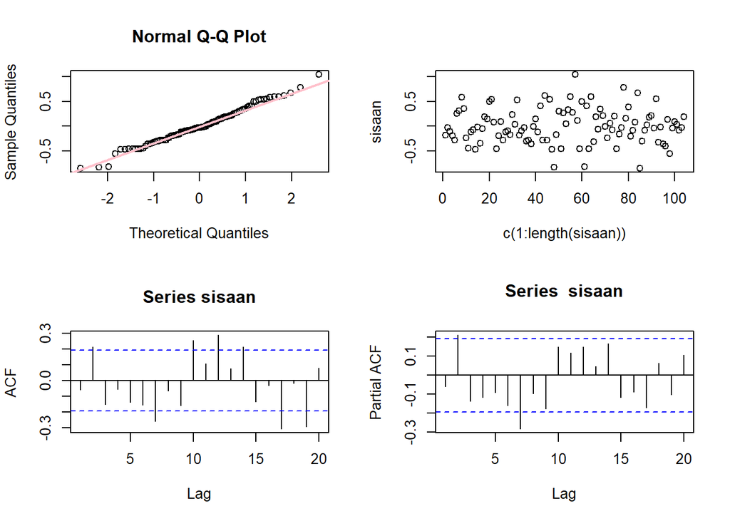

```r
sisaan <- model5$residuals
par(mfrow=c(2,2))
qqnorm(sisaan)
qqline(sisaan, col = "pink", lwd = 2)
plot(c(1:length(sisaan)),sisaan)
acf(sisaan)
pacf(sisaan)
```

```r
par(mfrow = c(1,1))
```

Berdasarkan plot kuantil-kuantil normal, secara eksplorasi ditunjukkan sisaan menyebar normal mengikuti garis $45^{\circ}$. Kemudian dapat dilihat juga lebar pita sisaan yang cenderung sama menandakan bahwa sisaan memiliki ragam yang homogen. Akan tetapi, plot ACF dan PACF sisaan ARIMA(3,0,2) signifikan pada lag ke-2 sehingga sisaan tidak saling bebas. Kondisi ini akan diuji lebih lanjut dengan uji formal.

## Uji Formal

```r
#1) Sisaan Menyebar Normal
ks.test(sisaan,"pnorm")  #tolak H0: sisaan tidak menyebar normal
```

```
##
##  Asymptotic one-sample Kolmogorov-Smirnov test
##
## data:  sisaan
## D = 0.28035, p-value = 1.588e-07
## alternative hypothesis: two-sided
```

Selain dengan eksplorasi, asumsi tersebut dapat diuji menggunakan uji formal. Pada tahapan ini uji formal yang digunakan untuk normalitas adalah uji Kolmogorov-Smirnov (KS). Hipotesis pada uji KS adalah sebagai berikut.

$H_0$ : Sisaan menyebar normal

$H_1$ : Sisaan tidak menyebar normal

Berdasarkan uji KS tersebut, didapat *p-value* sebesar 1.588e-07 yang kurang dari taraf nyata 5% sehingga tolak $H_0$ dan menandakan bahwa sisaan tidak menyebar normal. Hal ini tidak sesuai dengan hasil eksplorasi menggunakan plot kuantil-kuantil normal.

```r
#2) Sisaan saling bebas/tidak ada autokorelasi
Box.test(sisaan, type = "Ljung")  #tak tolak H0: sisaan saling bebas
```

```
##
##  Box-Ljung test
##
## data:  sisaan
## X-squared = 0.36708, df = 1, p-value = 0.5446
```

Selanjutnya akan dilakukan uji formal untuk kebebasan sisaan menggunakan uji Ljung-Box. Hipotesis yang digunakan adalah sebagai berikut.

$H_0$ : Sisaan saling bebas

$H_1$ : Sisaan tidak tidak saling bebas

Berdasarkan uji Ljung-Box tersebut, didapat *p-value* sebesar 0.5446 yang lebih besar dari taraf nyata 5% sehingga tak tolak $H_0$ dan menandakan bahwa sisaan saling bebas.

```r
#3) Sisaan homogen
Box.test((sisaan)^2, type = "Ljung")  #tak tolak H0: sisaan homogen
```

```
##
##  Box-Ljung test
##
## data:  (sisaan)^2
## X-squared = 0.24279, df = 1, p-value = 0.6222
```

Hipotesis yang digunakan untuk uji kehomogenan ragam adalah sebagai berikut.

$H_0$ : Ragam sisaan homogen

$H_1$ : Ragam sisaan tidak homogen

Berdasarkan uji Ljung-Box terhadap sisaan kuadrat tersebut, didapat *p-value* sebesar 0.6222 yang lebih besar dari taraf nyata 5% sehingga tak tolak $H_0$ dan menandakan bahwa ragam sisaan homogen.

```r
#4) Nilai tengah sisaan sama dengan nol
t.test(sisaan, mu = 0, conf.level = 0.95)  #tak tolak h0: nilai tengah sisaan sama dengan 0
```

```
##
##  One Sample t-test
##
## data:  sisaan
## t = 0.10067, df = 103, p-value = 0.92
## alternative hypothesis: true mean is not equal to 0
## 95 percent confidence interval:
##  -0.06497785  0.07192681
## sample estimates:
##   mean of x
## 0.003474481
```

Terakhir, dengan uji-t, akan dicek apakah nilai tengah sisaan sama dengan nol. Hipotesis yang diujikan sebagai berikut.

$H_0$ : nilai tengah sisaan sama dengan 0

$H_1$ : nilai tengah sisaan tidak sama dengan 0

Berdasarkan uji-ttersebut, didapat *p-value* sebesar 0.92 yang lebih besar dari taraf nyata 5% sehingga tak tolak $H_0$ dan menandakan bahwa nilai tengah sisaan sama dengan nol.

# Overfitting

Tahapan selanjutnya adalah *overfitting* dilakukan dengan menaikkan orde AR(p) dan MA(q) dari model ARIMA(3,0,2) untuk melihat apakah terdapat model lain yang lebih baik dari model saat ini. Kandidat model *overfitting* adalah ARIMA(3,1,2), ARIMA(3,0,3), dan ARIMA(4,0,2).

## ARIMA(3,1,2)

```r
modelover1=Arima(train.ts, order=c(3,1,2),method="ML")
summary(modelover1) #123.04
```

```
## Series: train.ts
## ARIMA(3,1,2)
##
## Coefficients:
##          ar1     ar2      ar3      ma1      ma2
##       0.3040  0.0129  -0.4761  -0.7330  -0.2670
## s.e.  0.1597  0.1252   0.0946   0.1734   0.1698
##
## sigma^2 = 0.1713:  log likelihood = -55.52
## AIC=123.04   AICc=123.92   BIC=138.85
##
## Training set error measures:
##                      ME      RMSE       MAE        MPE     MAPE      MASE
## Training set 0.02520772 0.4017457 0.3200527 0.06561246 1.045755 0.6791393
##                    ACF1
## Training set 0.02372784
```

```r
lmtest::coeftest(modelover1) #ar2 dan ma2 tidak signifikan
```

```
##
## z test of coefficients:
##
##      Estimate Std. Error z value  Pr(>|z|)
## ar1  0.303996   0.159661  1.9040   0.05691 .
## ar2  0.012912   0.125158  0.1032   0.91783
## ar3 -0.476127   0.094571 -5.0346 4.788e-07 ***
## ma1 -0.733005   0.173367 -4.2281 2.357e-05 ***
## ma2 -0.266995   0.169819 -1.5722   0.11590
## ---
## Signif. codes:  0 '***' 0.001 '**' 0.01 '*' 0.05 '.' 0.1 ' ' 1
```

## ARIMA (3,0,3)

```r
modelover2=Arima(train.ts, order=c(3,0,3),method="ML")
summary(modelover2) #107.78
```

```
## Series: train.ts
## ARIMA(3,0,3) with non-zero mean
##
## Coefficients:
##           ar1     ar2      ar3     ma1     ma2     ma3     mean
##       -0.0918  0.0445  -0.8294  0.6437  0.3091  0.5856  30.4826
## s.e.   0.0817  0.0664   0.0725  0.1319  0.1330  0.0920   0.0495
##
## sigma^2 = 0.1487:  log likelihood = -45.89
## AIC=107.78   AICc=109.29   BIC=128.93
##
## Training set error measures:
##                        ME      RMSE       MAE         MPE      MAPE      MASE
## Training set 0.0008165887 0.3723791 0.3003866 -0.01234541 0.9820417 0.6374088
##                    ACF1
## Training set 0.04254914
```

```r
lmtest::coeftest(modelover2) #ar1 dan ar2 tidak signifikan
```

```
##
## z test of coefficients:
##
##            Estimate Std. Error  z value  Pr(>|z|)
## ar1       -0.091844   0.081692  -1.1243   0.26090
## ar2        0.044498   0.066396   0.6702   0.50274
## ar3       -0.829399   0.072470 -11.4447 < 2.2e-16 ***
## ma1        0.643666   0.131930   4.8789 1.067e-06 ***
## ma2        0.309072   0.133003   2.3238   0.02014 *
## ma3        0.585590   0.091960   6.3679 1.917e-10 ***
## intercept 30.482570   0.049472 616.1626 < 2.2e-16 ***
## ---
## Signif. codes:  0 '***' 0.001 '**' 0.01 '*' 0.05 '.' 0.1 ' ' 1
```

## ARIMA(4,0,2)

```r
modelover3=Arima(train.ts, order=c(4,0,2),method="ML")
summary(modelover3) #98.72
```

```
## Series: train.ts
## ARIMA(4,0,2) with non-zero mean
##
## Coefficients:
```

```
##          ar1      ar2     ar3     ar4      ma1     ma2     mean
##       1.3902  -1.2647  0.2714  0.1327  -0.9716  0.9979  30.4733
## s.e.  0.0988   0.1678  0.1678  0.0994      NaN     NaN   0.0731
##
## sigma^2 = 0.1285:  log likelihood = -41.36
## AIC=98.72   AICc=100.24   BIC=119.88
##
## Training set error measures:
##                       ME     RMSE       MAE          MPE      MAPE     MASE
## Training set 0.004402388 0.346207 0.2753716 0.0001417827 0.9008244 0.584328
##                    ACF1
## Training set 0.03517991
```

```r
lmtest::coeftest(modelover3) #ar3, ar4, ma1, dan ma2 tidak signifikan
```

```
##
## z test of coefficients:
##
##            Estimate Std. Error  z value  Pr(>|z|)
## ar1        1.390171   0.098814  14.0685 < 2.2e-16 ***
## ar2       -1.264679   0.167843  -7.5349 4.887e-14 ***
## ar3        0.271373   0.167774   1.6175    0.1058
## ar4        0.132718   0.099426   1.3348    0.1819
## ma1       -0.971632        NaN      NaN       NaN
## ma2        0.997897        NaN      NaN       NaN
## intercept 30.473336   0.073128 416.7132 < 2.2e-16 ***
## ---
## Signif. codes:  0 '***' 0.001 '**' 0.01 '*' 0.05 '.' 0.1 ' ' 1
```

Dari ketiga model overfitting, didapatkan nilai AIC yang lebih besar daripada AIC model sebelum dioverfitting. Selain itu, beberapa parameter di ketiga model yang dioverfitting tersebut juga tidak signifikan. Oleh karena itu, model yang dipilih adalah model sebelum dioverfitting, yaitu ARIMA(3,0,2) karena memiliki AIC paling kecil dan semua parameternya signifikan.

# Peramalan

Peramalan dilakukan menggunakan fungsi `forecast()` . Contoh peramalan berikut ini dilakukan untuk 26 periode ke depan.

```r
ramalan <- forecast::forecast(model5, h = 26)
ramalan
```

```
##     Point Forecast    Lo 80    Hi 80    Lo 95    Hi 95
## 105       30.75616 30.29014 31.22219 30.04344 31.46889
## 106       30.17941 29.66096 30.69785 29.38652 30.97230
## 107       29.95892 29.42949 30.48835 29.14922 30.76861
## 108       30.28785 29.75685 30.81885 29.47576 31.09994
## 109       30.81916 30.28813 31.35018 30.00702 31.63129
## 110       31.00841 30.47748 31.53935 30.19642 31.82041
## 111       30.66108 30.13007 31.19209 29.84897 31.47319
## 112       30.12755 29.59634 30.65876 29.31513 30.93996
## 113       29.94741 29.41621 30.47861 29.13501 30.75981
## 114       30.30269 29.77148 30.83389 29.49028 31.11510
## 115       30.83343 30.30209 31.36478 30.02081 31.64605
## 116       31.00217 30.47086 31.53348 30.18960 31.81474
## 117       30.63809 30.10676 31.16942 29.82550 31.45069
## 118       30.10991 29.57844 30.64138 29.29710 30.92272
## 119       29.95243 29.42100 30.48387 29.13967 30.76520
## 120       30.32503 29.79357 30.85649 29.51224 31.13782
## 121       30.85035 30.31875 31.38194 30.03734 31.66335
## 122       30.99648 30.46492 31.52804 30.18353 31.80943
## 123       30.61554 30.08395 31.14712 29.80255 31.42852
## 124       30.09332 29.56160 30.62504 29.28012 30.90652
## 125       29.95860 29.42692 30.49028 29.14546 30.77174
## 126       30.34770 29.81599 30.87941 29.53452 31.16088
## 127       30.86657 30.33472 31.39842 30.05318 31.67996
## 128       30.98982 30.45802 31.52163 30.17650 31.80315
## 129       30.59275 30.06091 31.12459 29.77937 31.40613
## 130       30.07748 29.54550 30.60945 29.26389 30.89106
```

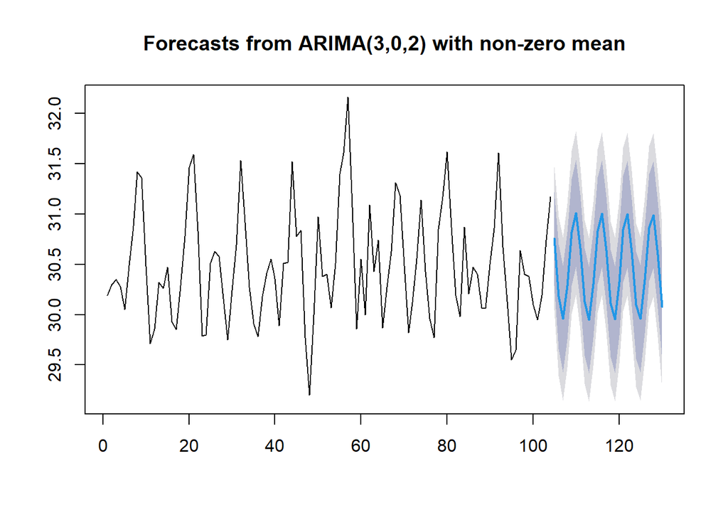

```r
data.ramalan <- ramalan$mean
plot(ramalan)
```

Berdasarkan hasil plot ramalan di atas, dapat dilihat bahwa ramalan ARIMA(3,0,2) memiliki pola naik-turun (musiman) hingga akhir periode.

Selanjutnya, dapat dicari nilai akurasi antara hasil ramalan dengan data uji sebaga berikut.

```r
perbandingan<-matrix(data=c(head(test.ts, n=26), data.ramalan),
                     nrow=26,ncol=2)
colnames(perbandingan)<-c("Aktual","Hasil Forecast")
perbandingan
```

```
##       Aktual Hasil Forecast
##  [1,]  30.80       30.75616
##  [2,]  30.41       30.17941
##  [3,]  30.07       29.95892
##  [4,]  30.14       30.28785
##  [5,]  30.24       30.81916
##  [6,]  30.61       31.00841
##  [7,]  30.40       30.66108
##  [8,]  29.92       30.12755
##  [9,]  29.80       29.94741
## [10,]  30.19       30.30269
## [11,]  30.44       30.83343
## [12,]  31.49       31.00217
## [13,]  30.95       30.63809
## [14,]  30.12       30.10991
## [15,]  30.32       29.95243
## [16,]  30.27       30.32503
## [17,]  30.42       30.85035
## [18,]  30.76       30.99648
## [19,]  30.39       30.61554
## [20,]  30.35       30.09332
## [21,]  30.08       29.95860
## [22,]  30.59       30.34770
## [23,]  31.03       30.86657
## [24,]  31.56       30.98982
## [25,]  31.06       30.59275
## [26,]  30.17       30.07748
```

```r
accuracy(ts(data.ramalan), head(test.ts,n=26))
```

```
##                 ME      RMSE       MAE        MPE     MAPE      ACF1 Theil's U
## Test set 0.0108344 0.3017523 0.2566012 0.02811024 0.837928 0.4882842 0.6796075
```

Dari hasil diperoleh nilai MAPE sebesar 0.837928, artinya model ini sudah baik dalam meramalkan periode-periode kedepannya.